# Periodic Table of Information

Whoever is committing to this repo, that's [whometh](http://andromeda.rutgers.edu/~jlynch/Writing/w.html#whom)

Jan 19, 2017 (last updated)

# Topics

1. Philosophy : Why Philosophy, Why Now?
2. Identity : Cybernetic Identity
3. Industry : Infocologically-sane Industries
4. Society : Bounded Rationality, Boolean Satisfiable Equilibriums: Conjectures and Refutations Model of Social Normativity
5. Banking : The New Measurement Paradox and Fiduciary Instrumentation
6. Technology : Blockchains and Distributed Resource-oriented Architecture
7. Questions : Inquiry? Comments?

# Philosophy: Why Philosophy, Why Now?

# Identity: Cybernetic Identity

# Industry: Infocologically-sane Industries

# Society: Bounded Rationality, Boolean Satisfiable Equilibriums: Conjectures and Refutations Model of Social Normativity

# Banking: The New Measurement Paradox and Fiduciary Instrumentation

# Technology : Blockchains and Distributed Resource-oriented Architecture

# Questions : Inquiry? Comments?

# Deprecated: Basic issue of privacy

```
“Since everything lies open to view there is nothing to explain. For what
is hidden, for example, is of no interest to us” (no.126).
— Ludwig Wittgenstein
```

L.W. was talking about zero knowledge systems of private transactions: “transaction at a distance”.

The private language argument is a channel coding problem in disguise. Funny, that!

# Basic issue of privacy (redux)

```
With democracy stalled at the Web access starting gate, our ability to assert
dissention is regulated by the folks who make the rules. Rules we don't
really even know about. There is a fundamental flaw in the basic reference
architecture that defines the Internet system itself. It's built on an
inadvertent misapplication of transaction identity rules to people identity
requirements. This is bad business practice and about to get worse.
— [Model of Everything](http://www.google.com/patents/US7774388).
— Margaret Runchey. Late 2007.
```

# Double Spend Attacks Happen All The Time

http://respends.thinlink.com/

We just drop them silently.

# Getting Started

- TCP for the Web?
- [STOMP](http://jmesnil.net/stomp-websocket/doc/)
- [DualApi](https://github.com/plediii/dualapi)

Establishing a simple protocol to support a logical layer for REQ-TCP simulation within REST to align and shape hardware drivers at a lower layer.

# Metaphor Today: Smalltalk and Cyberspace

```
Smalltalk's design--and existence--is due to the insight that everything we
can describe can be represented by the recursive composition of a single kind
of behavioral building block that hides its combination of state and process
inside itself and can be dealt with only through the exchange of messages.
— smalltalk: philosophy, metaphor, semantics, syntax
— http://billkerr2.blogspot.com/2007/09/smalltalk-philosophy-metaphor-semantics.html
```

# Opentalk

- Smalltalk Selectors: Message selectors (such as +) are called selectors because they select properties from the receiving object.
- Smalltalk Cells : Biological cell, whose contents of the cell are protected or encapsulated and that they respond to messages from outside.
- Smalltalk Monads: unary, binary and keyword: That selects the part of my mind that thinks about directions.

https://docs.openchain.org/en/latest/api/ledger.html

# Privacy and Meaning

> MILLER: "Let me appeal as you did to the Blue River. Suppose I take a visitor to the stretch of river by the old Mill, and then drive him toward Manhatten. After an hour-or-so drive we see another stretch of river, and I say, “That’s the same river we saw this morning.” As you pointed out yesterday, I don’t thereby imply that the very same molecules of water are seen both times. And the places are different, perhaps a hundred miles apart. And the shape and color and level of pollution might all be different. What do I see later in the day that is identical with what I saw earlier in the day?"

> WEIROB “Nothing except the river itself."

> MILLER: “Exactly. But now notice that what I see, strictly speaking, is not the whole river but only a part of it. I see different parts of the same river at the two different times. So really, if we restrict ourselves to what I literally see, I do not judge identity at all, but something else."

> — A Dialogue on Personal Identity and Immortality. Perry, John.

An example of "mereology" (study of part-whole relationships) being used in a practical argument to get under an atheist's skin.

# Periodic Table of Information + Canonical Record System

```
U 0. ALL EVENTS - EVERYTHING
R 1.0. EVENT ASSERTIONS                 1.1. EVENT OBJECTS
A 1.0.0. PRINCIPLE  1.0.1. TRANSACTION  1.1.0. PERSON   1.1.1. PROPERTY
```

A syntax to express aggregation, explication, etc. for cyberspace.

What is *in* cyberspace? More importantly: How does cyberspace hang together?

# Identity

```
Ontology      Mode             Metastructure   Domain         Sector        Knowledge
People        (Attributal)     Social          Attribution    Social        Functional Phenomenology (Epistemology)   Amorous       Legal           Psychological   Thought As        Decentralized   Virtual       Embodied    Local      Datum    Particle    Postulate     Amorous     Absolute      Null
Corporations  (Relational)     Aesthetical     Context        Banking       Econometrics                              Economical    Physical        Material        Extension As      Centralized     Virtual       Embodied    Nonlocal   Object   Thing       Referent      Aesthetic   Objective     One
Content       (Attitudinal)    Political       Narration      Industry      Cybernetics                               Ethical       Moral           Cultural        Thought As If     Decentralized   Distributed   Artificial  Local      Value    Idea        Proposition   Politic     Subjective    Multiple
Machines      (Extensional)    Biological      Value          Blockchain    Infocology                                Chemical      Environmental   Physiological   Extension As If   Centralized     Distributed   Artificial  Nonlocal   Energy   Wave        Measurement   Biologic    Relative      Infinite
```

Too Spinozistic? *Probably*. To put it another way:

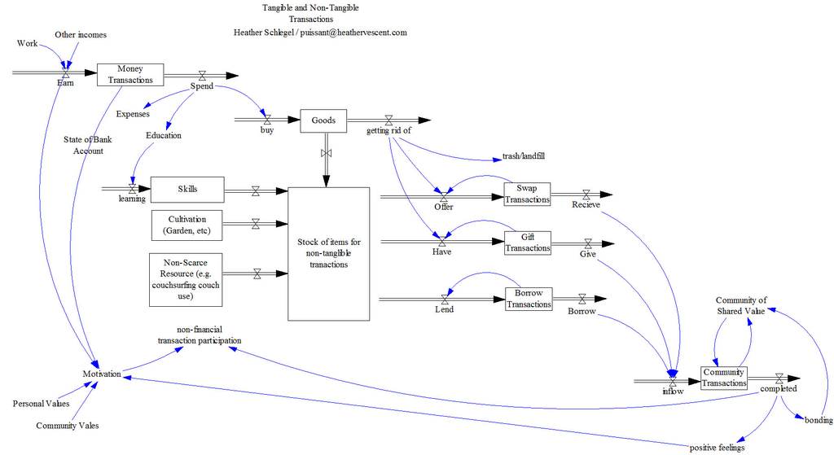

Futurist Heather Schlegel's narratological metastructure of heterogeneous transactions.

# People: From Justice

- StoryBook Generators (Narratology)
- Minimalistic School (Computational Linguistics)
- HLA Hart (Retributive Justice, Rule of Recognition)
- Telepathy as Folk Identity  
  We have misapplied telepathy: why should the amorous mode of reality be grammaticalized by corporate identity as economic performance or static theory of efficiency about law or aged science of messages themselves? Telepathy is the aggregate shift of musical, folk identity — who are ‘we’ for any Rule of Recognition?

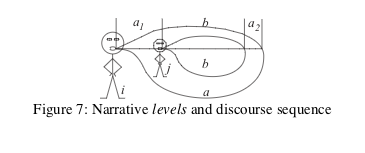

# Corporations: From Fairness

- Rule of Recognition
- Fairtrade
- NAFTA
- [EDGAR](https://www.sec.gov/edgar/searchedgar/companysearch.html)
- DUNS Number
- Banks
- Federal
- Factom

## Oops

- EDI/SAP/Google Health tragedy of the commons

Interoperable? Continuous? Federated?

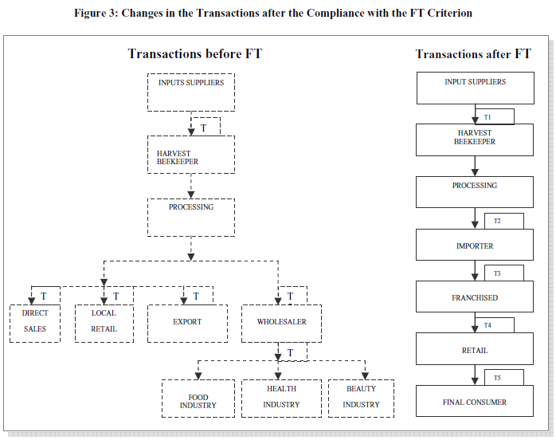

The governance of fair trade system: evidence from small honey producers in Rio Grande do Sul

# Content: From Provenance

- P2P Platforms
- The Web
- W3C
- Bittorent
- JS (Stripe, jQuery, CDN, etc.)
- Ascribe ([SPOOL](https://github.com/ascribe/spool))
- ChangeTip
- Telecommunications

## Opps

- bitcongress

Decentralized? Distributed? Authorized?

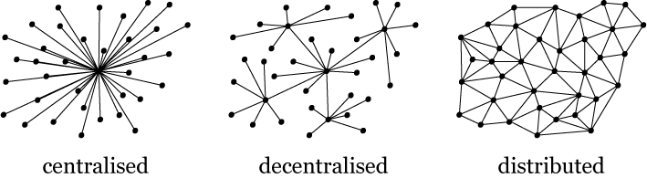

# Machines: From Rule

- CRISPR
- Transaction Continuums: Bitcoin, Ethereum, etc.; Transactions open to View (privacy)
- See [Blockchains wiki](https://gitlab.com/nerdfiles/knowledge-base/blob/master/Blockchains.wiki).

## Opps

- Permissions Debate
- Blocksize Debate
- Web Accessibility
- SEO and SPAs
- JSONAPI
- Publishing — yuck! Regulatory nightmares. Fees. Authoritative?
- Banks have the same problems as Academics — static theory over dynamic living cybernetic reality.

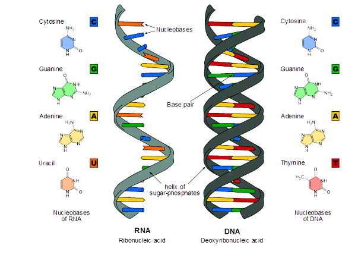

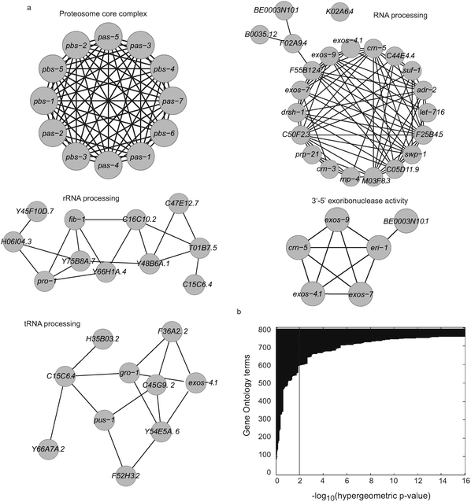

# Mathematics is ontology

Establishing mathematical models based on negative cycle detection:

```
Notice    TRX
Related   TRX
Continue  TRX
Organize  HVM
Order     HVM
Rearrange HVM
```

Abstract, generalize Nakamoto/Piketty to establish a mathematical definition of Respect:

```
Compute identity statements for entity sets on weighted acyclic graphs.
```

This assert of Respect is applicable to Machines, Corporations, People, Content. The model itself above is a minimalistic framework for discovery of respect relations. Applying a algebraic matrix of identity statements as the total aggregation of URA atoms (a notion of factivity, or the Order of Factivity).

We might also call this a Mathematical Definition of HLA Hart’s Rule of Recognition. Learn more about the [discretion thesis](http://www.iep.utm.edu/legalpos/#H3).

Judging such equivalence, we might arrive at a demonstration such that

```
t = dv^2

transaction_event = data * value squared
```

# More Platforms, More Problems

- Infinitude of applications, all of which require similar ID reqs  
  ** Tokenized Action Spaces  
  ** “E-mail and password”
- Bank in a Box  
  ** Most apps are  
  ** Ontological formaulations or reformulations of identity data (Explication)  
  ** User interfaces or interaction methods given the medium they are accessed through (bounded explication).
- Deploy  
  ** Apps are aesthetically congruent methods of communication  
  ** Determined by the user’s wants, needs, desires of  
  ** inbound or outbound informatioin

[figure not shown]

# Component Level Digital Signing

- Code Signed Continuous Build Processes
- E2E Encryption (JScrambler, seifnode, etc.)
- Sandboxed Personas
- Machine-to-Machine Identity  
  ** Surrogate Identity  
  ** Metanomic Identity  
  ** Hyperdata
- Content-to-Content Identity  
  ** Automated Identity  
  ** Identity encoded into Quantum Algorithms (no measurement approach)  
  ** Stateless Quantum Events

# Logarithmic Category Systems

- Classifiers
- Bitcoin
- Software-defined Communications  
  ** Perceptron Modeling of QLS/QLD interactions, logical event spaces, etc.  
  ** Frequency-based Fault Tolerant Systems
- State Machine Structural Relations  
  ** “Web is fundamentally a distributed hypermedia application.”  
  ** “Web is the most hostile development environment imaginable.”
- Prediction Machines (Link Prediction, Transaction Prediction)

# Logarithmic Measurement

- Logarithmic Categories  
  ** discovered based on predictions about Log Pairs
- Generalized Adjunction
- to determine inductional structure (metastructure)
- Logarithmic Ramification
- between Pairs to extend nonconstant, holomorphic maps (birational surface of hardware layer constraints)

# Constructivistic Advantage

- Logarithmic Metastructure Systems: Building network interfaces from generated log pairs.
- Logarithmic Block Universe based on Category Equalisation

# Existing Ideas

- IPFS
- “Infocology”
- W3C
- MaidSafe, Storj, “Bitcoin”, Dogecoin, CryptoNote, Darkcoin, Monero, Potcoin, Satoshi Dice, ChangeTip, -- lots of “metadata”.

Who creates the Standard cannot be allowed to assume the hyperparameters of Identity (metastructures).

Applies boolean satisfiable ideal information channel model:

```
γ(σ) = log(α − β)
```

Where else can this be applied?

# Natura Naturata as Logical Layer

```
Transitive Metastructures      (Notice TRX)
‘Pataphysics of Metastructure  (Related TRX)
Countable Metastructures       (Continue TRX)
```

- Transmedia Transaction Model
- Non-natural, Non-neutral Information
- Information - Meaning = Data

# Natura Naturatans as Logical Layer

```
Ontological Plenitude of Metastructure  (Organize HVM)
Modal Transfer of Metastructure         (Order HVM)
Principle of Sufficient Reason          (Rearrange HVM)
```

- Hypermedia View Model
- No brute facts, “Quine’s Variable”
- Information = Data + Meaning

# Transitive Metastructures

Thinking: “[represent] the maximum possible equilibrium between belonging and inclusion ... [It] is the ontological schema for normality.

Extended: a probability amplification technique applied to amplify the assignment which maximizes the number of weighted clauses, encoded into quantum algorithm that treated transmitted states, not enduring calculation/measurement itself ( cost of observation)

# Language and Memory with ‘Patadata

Metastructures are measured using the engine of ‘Pataphysics:

```
Syzygy    (converse of axiom schema of epislon-separation)
Clinamen  (converse of axiom of union)
Antimony  (converse of axiom of pairing)
Anomaly   (converse of axiom of empty set)
          ‘Difference which makes a difference.’
          Repressed part of the rule that ensures its exception.
          Interferent information.
Absolute  (converse of axiom of induction)
‘Pataphor (converse of axiom of extensionality)
???       (converse of axiom schema of epislon-collection)
```

# Nondenumerable Metastructure

One as an operation on 4 categories of metadata:

```
social        (ghost in the machine)
aesthetical   (dadata)
political     (power set through puns)
biological    (singularities)
```

# Epistemic Problems

- Semantic Information is like Analytic Knowledge
- `{Concepts,Ideas}.reduce(GettierProblem)`

# Technological Problems

- ‘To what degree does the media-type support machine-to-machine interactions?’
- ‘Does the media-type work for more than one application protocol (HTTP, FTP, etc.)?’
- Enter *transmedia modeling*, then *degradable media models*.

# Knowledge as JTB, Information as MFN

```
S is information iff
    [S is meaningful]
    [S is well-formed]
    [S is not null]

S knows p iff
    [S believes p]
    [S has evidence for p]
    [p is true]

S trusts that p iff
    [S authenticates p]
    [S authorizes p]
    [S amoritizes p]
```

# Information as Communicative Texture

```
$ is information iff
    [S is well-formed]
    [S is not null]
```

Mathematical Theory of Communications: NP

# Information as Communicative Praxis

```
$ is information iff
    [S is meaningful]
    [S is not null]
```

Logarithmic Metastructure: BQP

# Classical Information Model, CIM

```
S is information iff
    [S is purposeful]
    [S is well-formed]
    [S is not null]
```

Properties:

- Low Entropy
- Reliable Metastructure
- Small Data Deficit
- Infocologically Conservative
- Cantor’s Paradise

# Minimalistic Information Model, MIM

```
S is information iff
   [S is purposeful]
   [S is not null]
```

Properties:

- High Entropy
- Low Metastructure
- Large Data Deficit (Digital Dark Age?)
- Information Surplus
- Maxwell’s Demon

# Conceptual Sphere Mapping

```
Belief ---------------- Justification ------------- Truth : Knowledge
|                                                       |
Human-meaningful        Decentralized              Secure : Zooko’s Triangle
|                                                       |
Identity                Accessibility        Availability : Information
|                                                       |
IAM                         SDQCP                  P2PFSM : Software-defined Realities
|                                                       |
AuthenToken              AuthorToken           AmortToken : Cybernetic Reality
|                                                       |
ID ------------------------- PTI -------------------- CRS : NextTech
```

- IAM: Web-ready Asset Management with Private Key Authentication as an Asset
- SDQCP: Software-defined Quantum Communication Protocol based on Log Pair encoding to quantum state event potential for shared measurement or side-channel stateless swap compute.
- P2PFSM: Distributed Finite State Machine with Stateless Value Generation

# Fault Tolerant Front Ends

- ft-html

# CRS (Historically inherits from Unitary Reference Architecture)

```
Event
Object
Entity
  Purpose
Transaction/Assertion
List
  Table
    Database
      Program
        Computer
          Intra-inter-extra network
            Global network
              Cyberspace
Group Mnemonics / Metanomic Identity
XYZT/gt
```

# Deflationary Orders of Trust for Distributed Cryptological Namespaces

Apply Kripkean Semantics to Cryptological Systems:

```
Uniqueness                 $         /aka/$President                        Possibility                       ◇
Persistence                _         /aka/_endurance                        Necessity                         □
Universality               -         /ui/btn--payment or /ui/p-text         Names                             Millianism
Scalability                .         /ui/WebPage.breadcrumb                 Conjunctive Inclusion             & or ^
Evolvability               +         /semver/1.0.0+38293/packageName        Disjunctive Inclusion             + or v
Opacity                    * (or **) /A/produces/A/ or /A/**/C              Arrow (Material Entailment)       ⊃ or >
No Side-effects            '         /savedRecord' (H Factor: LT)           Negation                          -
Global uniqueness          ()        /style/(idAttr)                        Universal Quantifier              () or ∀
Optional sameness          (())      /style/((className))                   Existential Quantifier            ∃ (quantifier exchange?) or `P(query=None)` (hopefully our API can be this simple)
Fully Non-dereferenceable  !         /document/!main                        definition                        ≔ or ≡
```

# Thereoms

```
 □(PK0→PKn) → (□PK0→□PKn)
~□(PK0→PKn) v (□PK0→□PKn)

it is necessary that
  if productivity-based income by a wide margin outpaces
      over long periods of time average return on investment

 □PK0 → □□PK0
~□PK0 v □□PK0

 ◊PK0 → □◊PK0
~◊PK0 v □◊PK0
```

# Key Distribution Formats, Ring Formats, Geometric Key Patterns

```
□PK0   → PK0         (reflexive key distribution)
□PK0   → □□PK0       (transitive [metastructure] key distribution)
□□PK0  → □PK0        (dense key distribution)
□PK0   → ◊PK0        (serial key distribution)
PK0    → □◊PK0       (symmetric key distribution)
◊PK0   → □◊          (Euclidean key distribution)
□(□PK0 → PK0) → □PK0 (well-founded key distribution; centralized hierarchical)
◊□PK0  → □◊PK0       (convergent key distrituion)
...
```

Assertion: Solving rebuild times with vector based key distributed node scaling.

Chains are NP hard problems, technically.

# Transformation/Logical Layer to Periodic Table of Information

```
Factivity Order        : False information is not stored.
                         (Rollback)
                         √ Persistence

Motive Order           : Only purposeful information is stored.
                         (Recovery/Checkpointing)
                         √ Uniqueness

Byzantine Order        : Node having information, i, is a Good Actor.
                         (Fuzzy Voting)
                         √ Scalability

Incept Assertion Order : Transmission of information, i, implies one has
                         run a checksum or smooth simulation internally.
                         (Rejuvenation)
                         √ Universality

Assertion Order        : If Node asserts p, then all machines can confirm
                         that Node knows p.
                         (Mask/Material Implication)
                         √ Opacity

Closure Order          : Node stores all deductions of p assuming Node
                         stores ancestry of p.
                         (Confinement/Reduction)
                         √ No Side-effects

Anti-luck Order        : Information excludes stochastic luck.
                         (Retry/Retransmission)
                         √ Optional sameness

Achievement Order      : Information is a technological achievement.
                         (Reconfig)
                         √ Global uniqueness

Ability Order          : If Node stores p, then the truth of Node’s motive
                         for p must have been ensured through the exercise
                         of Node’s relevant technological abilities.
                         (Diagnose/Adaptive N-version programming)
                         √ Evolvability

Non-local Order        : Some extension to the Achievement order.
                         (ft-html: <!doctype html><html ◈>)
                         √ Fully Non-dereferenceable
```

# Physical Layer Design Assumptions of Information

```
Distributed        : Interconnected by a high-bandwidth, low-latency network
High Availability  : Most nodes up most of the time
High Accessibility : Uncorrelated client node failures
Optimal Sharding   : No files are both: read by many users  and/or  frequently updated by at least one user
Byzantine          : Small but significant fraction of users will maliciously attempt to destroy or corrupt file data and metadata
Secure             : Large fraction of users may independently attempt unauthorized accesses
Provenance         : Each node is  under the control of its immediate user  and  cannot be subverted by other people
Immutable          : No user sensitive data persist after logout or system reboot
MTC                : Mathematical Theory of Communications
```

# Benefits: Fault Tolerance Strategies

```
Recovery Blocks
Self-check / Recursive Pingback (100s)
Re-express                      (100s, 200s)
Retry                           (200s, 300s)
N-versioning                    (semver; 300s, 400s)
N-copy                          (100s, 300s, 400s)
  * Consistent snapshotting     (e.g. this classic paper from Chandy and Lamport)
Adaptive N-version programming  (better than semver, distributed logging; 200s, 300s, 400s)
  * Leader election             (e.g. the Bully algorithm)
Fuzzy Voting                    (200s, 300s)
  * Consensus                   (2-phase commit)
Reconfig/Rejuvenation           (300s, 400s, 500s)
Abstraction/Mask                (200s, some 300s, 400s, 500s)
  BQP iff CASE                  (cognitive-tolerance abstraction specification encapsulation)
  * Distributed state machine replication
Parallel Graph Reduction        (PHT Prediction Modeling with Patricia Triemodel Pruning; 500s)[0]
```

HTML can handle that, and still be [lightweight](https://www.ampproject.org/).

# Beyond ‘the Cloud’

[figure not shown]

`programmable data` and `cloud developer`:

```
Inductive Metastructure of Code
On-demand Architecture
Distributed Resource-oriented Applications
Molecular Ads (Degradable Media Models)
Software-defined Machine Identity (Ma2Ma)
Software-defined Content Identity (Co2Co)
```

Servers be damned! `smart names` aren’t spam!

# Semiotic Alchemy

```
'That is: they deal with issues of significance. Moreover, what computer
science is, I believe—what history will recognise its 20th-century
instantiation to have been—is an experimental, synthetic precursor to the
emergence of this new theory: i.e., something I call semiotic alchemy. Think
of all those C++ and Java hackers, trying to turn web pages into gold! And
think, too, of the profusion of rag-tag, untheorised practices, conducted
in cottages, basements, and garages, that constitute “computing in the wild”:
they embody a vast wealth of pragmatic and practical understanding—just not
as-yet very well understood. It all makes such good sense. And it is
important. Computers are laboratories of middling complexity, between the
frictionless pucks and inclined planes of mechanics, and the full-blooded
complexity of the human condition, in terms of which to experiment with,
and come to understand, the primordial intentional dialectic.'
— "[God, Approximately](http://www.ageofsignificance.org/people/bcsmith/papers/smith-godapprox4.html)".
— Brian Cantwell Smith.
```

# Existing Trends

- They’re already doing it, apparently.
- But maybe these problems are the result of Gettier, and solutions are obscured by obscurity (entropy).

# Our Responses

- Positivist Strategies: P2P Government, Anonymous, Occupy, #feelthebern (hashtags), etc.
- Detached from Technology; Critical of Technology;
- Self-organizing, Entrenched in the Industrial Economies
- Negative Strategies: Tor, Bittorent and Bitcoin, Dark markets, DDoSing, Wikileaks, etc.
- Detached from Culture; Transhumanist in Nature
- Has anyone got an easy cross-platform setup for proxy switching? JavaScript? *shrug*

# Information and Belief

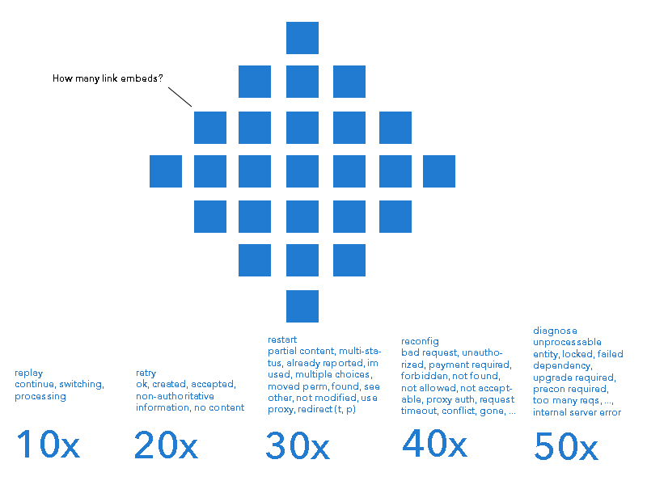

# Prospects

- MTC
- Gettier
- Logic Layer

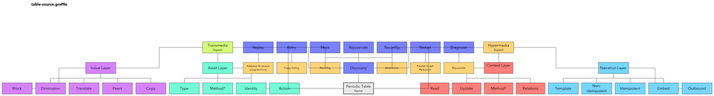

# Philosophical Problems

- Dual-aspect Zero Knowledge Systems
- NoDef Minimalistic Framework of Information

# Models: Existing Ideas

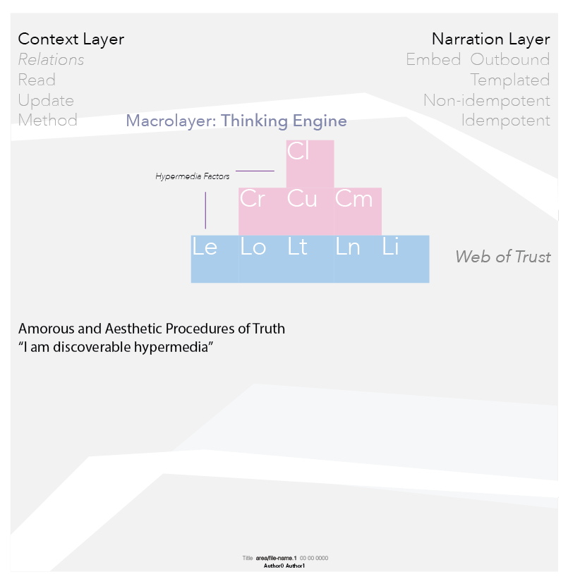

- Embodied Cognition
- Cogito
- “AI”

# Models: New Hotness on “Blockchains”

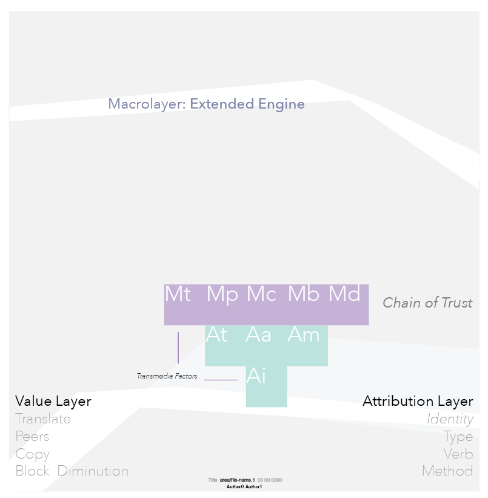

- p > q (Gambler’s Ruin Solution; Bitcoin solution)
- r > g (return of return to wealth versus economic growth rate)
- Any relation? (Pbbt.) What kind of statement is it?
- Conjecture, Prediction, Principle?
- Is Piketty’s Tax justified? Is Satoshi’s? For all Bad Actors?

Response: There’s no proof that high debt causes low wealth. Response: Redistribution of wealth engenders dependency, predistribution empowers. Response: Piketty is stating that society has made `r > g` a *good prediction*. Response: Bitcoin is only a *mathematical statement of the problem, not a solution*.

# Computationally Weak Forces

Computationally bound identity systems are hazardous and tend toward maximizing r > g. We must correct for this flaw of infocological artifacts.

# Synthesis of Ideas: Dual-aspect Integration

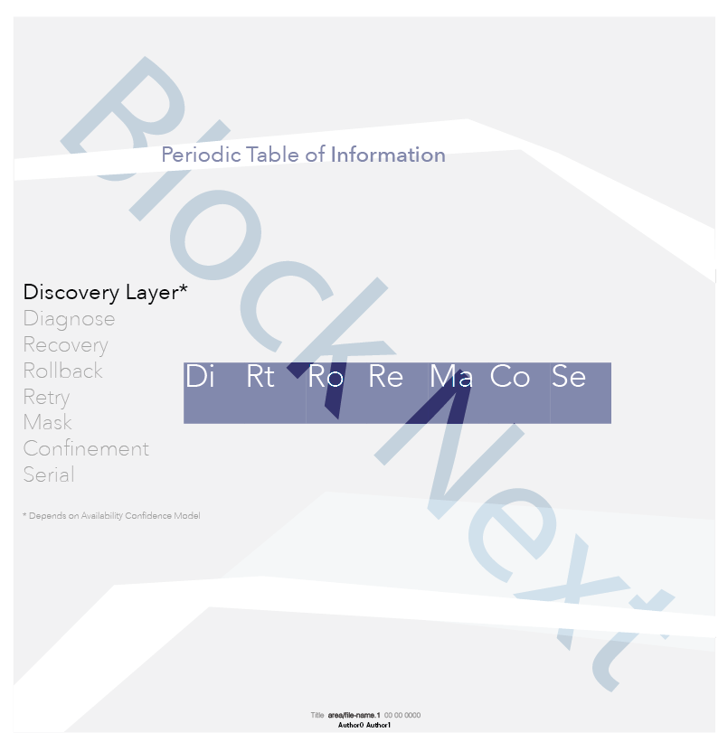

# Practical Infocology

Popper-Quine-Mill-Weisberg (Type-Q Materialism): “to be is to be a value of a bound variable”

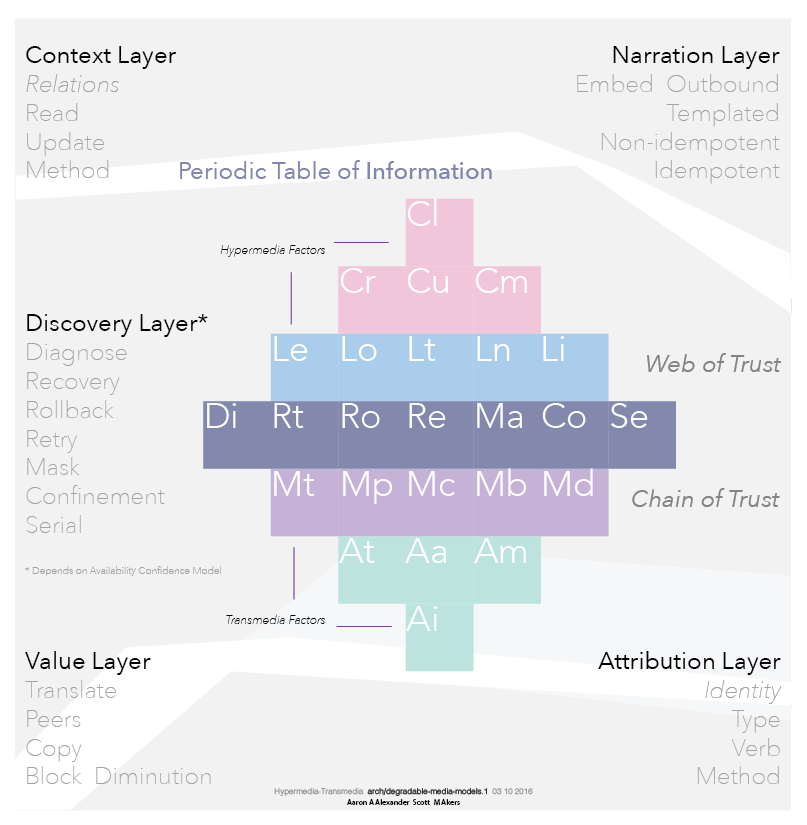

# Metamedia with Intent

[figure not shown]

Metamedia with Intent

# Metamedia with Intent

[figure not shown]

- Degradable Media Models (ARIA codes, metacodes, isotype languages for all filetypes): http://lcamtuf.coredump.cx/squirrel/
- Latent Accessibility of all Formats: https://en.wikipedia.org/wiki/List_of_file_formats
- Bu2Bu, Cu2Cu, Ma2Ma (machine-to-machine business), Co2Co (content-to-content business)

# Methodological Strategies

- Datalogical/Architectural Mass: Periodic Table of Information; new component to Web Science: infocology, infosthetics,
- Syntactic Entropy Modeling: PTI+CRS
- Pragmatics of Infosys: Organelles, Cells, Molecular Designs, etc.

A way to build apps (drapps) today: Distributed [Resource-oriented](http://roca-style.org/) Applications

- No Bytecode
- Metacodes expressed in posh.
- Quantizable State Machine
- Keyless (NoAPIKey) Identity